# Drawer Users

## 3.5 SSQ classification

We attempt to create a *decision tree* based on the SSQ-data, however unsuccesfully since there doesn’t seem to be a pattern.

*Base*

```r
df_ssq_base_group <- merge(df_ssq_base, df_use_group[,c(1, 11)], by='record_id')
df_ssq_base_group <- filter(df_ssq_base_group, !is.na(use_group))
#df_ssq_base_group <- na.omit(df_ssq_base_group)

set.seed(1234)
ind <- sample(2, nrow(df_ssq_base_group), replace = TRUE, prob=c(0.7, 0.3))
train.data <- df_ssq_base_group[ind == 1, ]

form_ssq_base <- use_group ~ ssq_speech_q1 + ssq_speech_q4 + ssq_speech_q10 + ssq_speech_q11 + ssq_speech_q12 + ssq_space_q6 + ssq_space_q9 + ssq_space_q13 + ssq_sound_q2 + ssq_sound_q7 + ssq_sound_q9 + ssq_sound_q14

tree <- ctree(form_ssq_base, data = train.data)
table(predict(tree), train.data$use_group)
```

```
##
##            Very low Low Medium High
##   Very low        0   0      0    0
##   Low             0   0      0    0
##   Medium          0   0      0    0
##   High          124 108    291  637
```

## 3.6 ioi classification

We CAN find patterns in the IoI classification. We are comparing the use_group and seeing whether or not the patients answers corresponds to their actual use_time from file *“HA_experience_use-time”*

```r
df_ioi_group <- merge(df_ioi, df_use_group[,c(1, 11)], by='record_id')
df_ioi_group <- filter(df_ioi_group, !is.na(use_group))
  #na.omit(df_ssq_base_group)

set.seed(1234)
ind <- sample(2, nrow(df_ioi_group), replace = TRUE, prob=c(0.7, 0.3))
train.data <- df_ioi_group[ind == 1, ]

form_ioi <- use_group ~ ioi_ha_1 + ioi_ha_2 + ioi_ha_3 + ioi_ha_4 + ioi_ha_5 + ioi_ha_6 + ioi_ha_7
form_ioi_no1 <- use_group ~ ioi_ha_2 + ioi_ha_3 + ioi_ha_4 + ioi_ha_5 + ioi_ha_6 + ioi_ha_7

tree_ioi <- ctree(form_ioi, data = train.data)
tree_ioi_no1 <- ctree(form_ioi_no1, data = train.data)
table(predict(tree_ioi), train.data$use_group)
```

```
##
##            Very low  Low Medium High
##   Very low       31   14     16    0
##   Low            35   57     53   19
##   Medium         19   32    118   70
##   High          154  124    397 1164
```

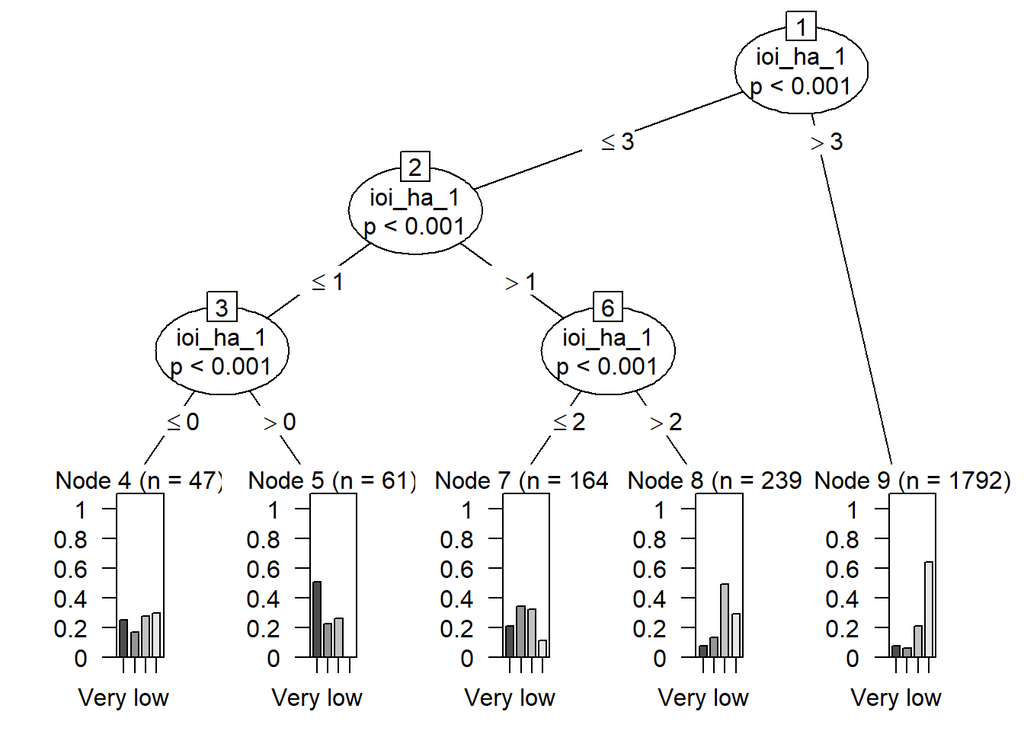

```r
plot(tree_ioi)
```

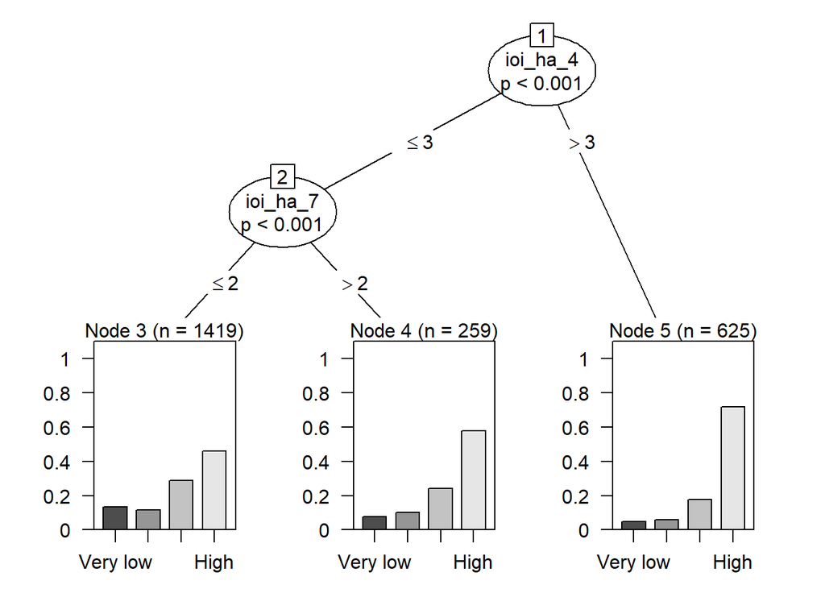

```r
plot(tree_ioi_no1)
```

## 3.7 15 D classification

```r
df_15d_base_group <- merge(df_15d_base, df_use_group[,c(1, 11)], by='record_id')
df_15d_base_group <- na.omit(df_15d_base_group)

set.seed(1234)
ind <- sample(2, nrow(df_15d_base_group), replace = TRUE, prob=c(0.7, 0.3))
train.data <- df_15d_base_group[ind == 1, ]

form_15d <- use_group ~ fifteen_d_1_move + fifteen_d_2_sight +fifteen_d_3_hear          +fifteen_d_4_breathe+fifteen_d_5_sleep+fifteen_d_6_eat+fifteen_d_7_speak+fifteen_d_8_pee+fifteen_d_9_activity+fifteen_d_10_mental+fifteen_d_11_unplesant+fifteen_d_12_depression+fifteen_d_13_stress+fifteen_d_14_power+fifteen_d_15_sex

tree_15d <- ctree(form_15d, data = train.data)
table(predict(tree_15d), train.data$use_group)
```

```
##
##            Very low Low Medium High
##   Very low        0   0      0    0
##   Low             0   0      0    0
##   Medium          0   0      0    0
##   High          120 116    283  609
```

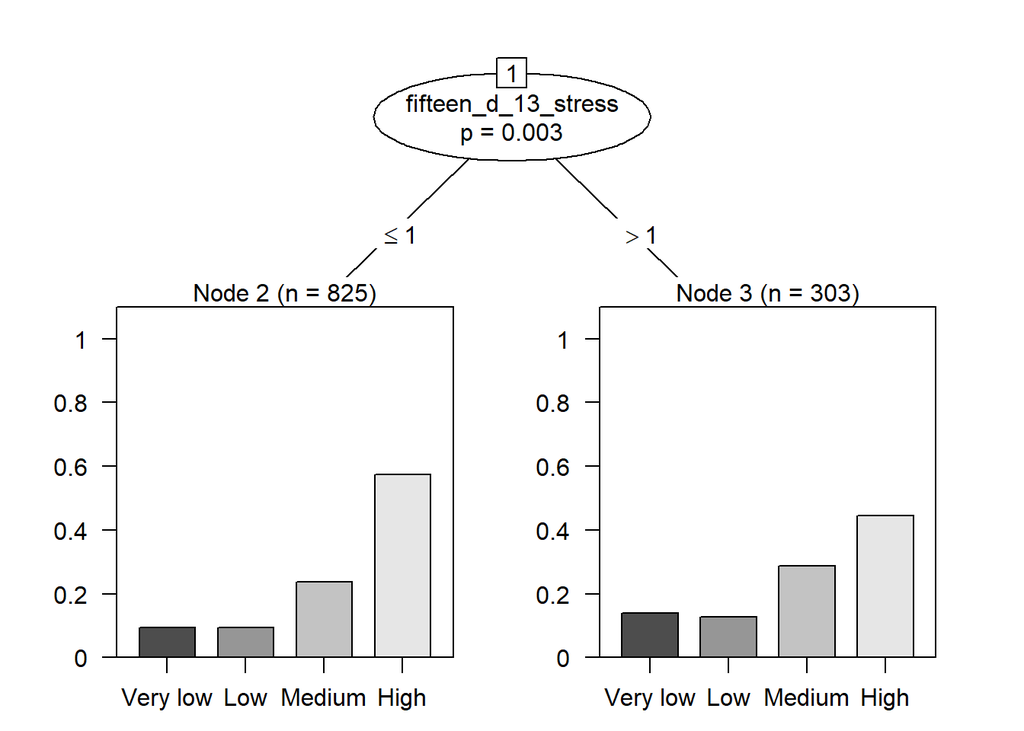

```r
plot(tree_15d)
```

## Fordelingen af audiogram typer over tid de bruger headset om dagen

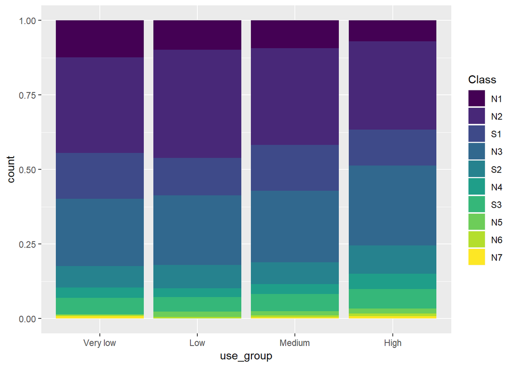

```r
ggplot(merge(df_use_group, df_audiogram, by=c("record_id"))) + geom_bar(aes(x=use_group, fill=Class), position = "fill")
```

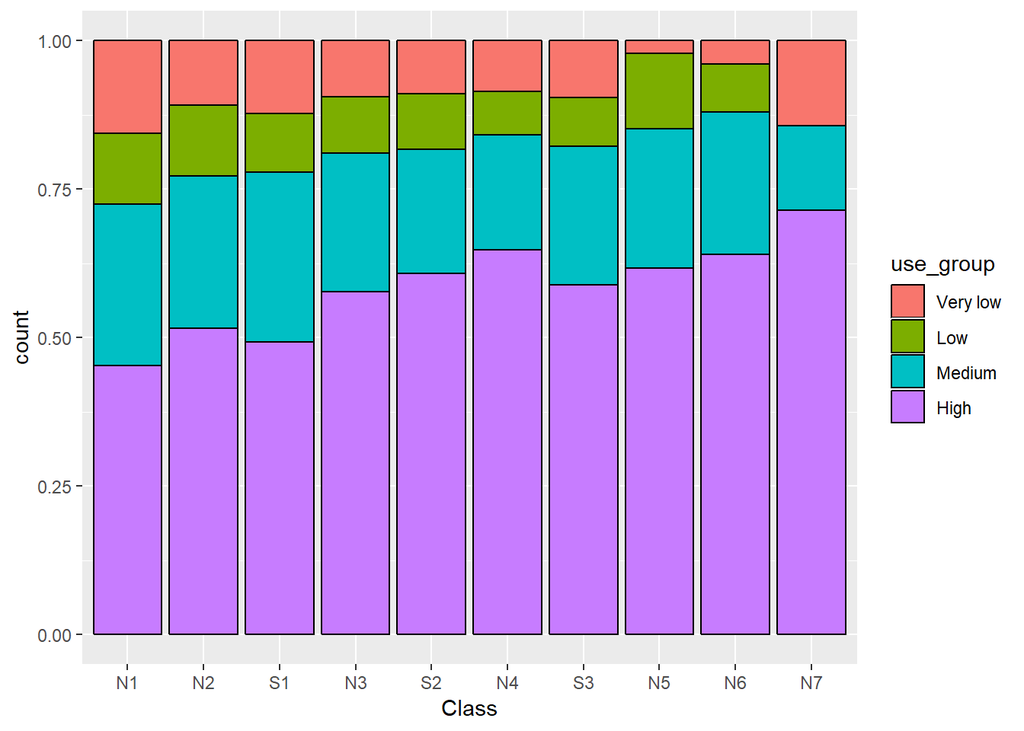

```r
ggplot(merge(df_use_group, df_audiogram, by=c("record_id"))) + geom_bar(aes(x=Class, y = ..count.., fill=use_group),
                          position = 'fill', stat = 'count', color = 'black')
```

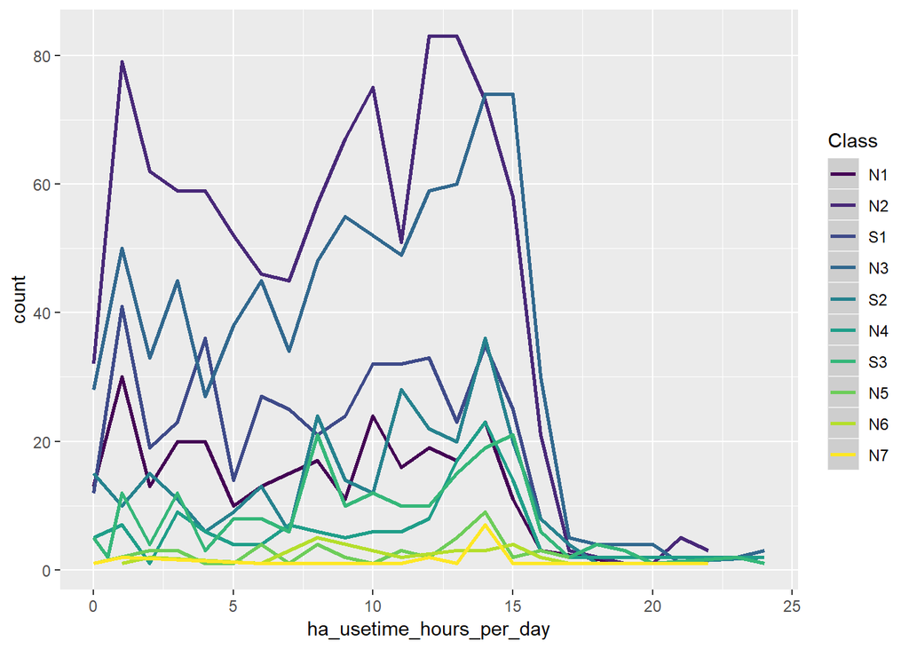

```r
ggplot(merge(df_use_group, df_audiogram, by=c("record_id"))) + geom_smooth(aes(x=ha_usetime_hours_per_day, y=..count.., color=Class), stat = 'count')
```